# Risk Factor Analysis

## Outcome Variable

**Outcome Variable:** whz

## Predictor Variables

**Intervention Variable:** mbmi

**Adjustment Set:**

- arm
- W_mage
- meducyrs
- feducyrs
- single
- brthmon
- W_parity
- delta_W_mage
- delta_meducyrs
- delta_feducyrs
- delta_single
- delta_brthmon
- delta_W_parity

## Stratifying Variables

The analysis was stratified on these variable(s):

- agecat
- studyid
- country

## Data Summary

| agecat | studyid | country | mbmi | n_cell | n |
| --- | --- | --- | --- | --- | --- |
| Birth | ki0047075b-MAL-ED | BANGLADESH | Normal weight | 183 | 209 |
| Birth | ki0047075b-MAL-ED | BANGLADESH | Underweight | 26 | 209 |
| Birth | ki0047075b-MAL-ED | BRAZIL | Normal weight | 56 | 61 |
| Birth | ki0047075b-MAL-ED | BRAZIL | Underweight | 5 | 61 |
| Birth | ki0047075b-MAL-ED | INDIA | Normal weight | 33 | 41 |
| Birth | ki0047075b-MAL-ED | INDIA | Underweight | 8 | 41 |
| Birth | ki0047075b-MAL-ED | NEPAL | Normal weight | 26 | 26 |
| Birth | ki0047075b-MAL-ED | NEPAL | Underweight | 0 | 26 |
| Birth | ki0047075b-MAL-ED | PERU | Normal weight | 216 | 221 |
| Birth | ki0047075b-MAL-ED | PERU | Underweight | 5 | 221 |
| Birth | ki0047075b-MAL-ED | SOUTH AFRICA | Normal weight | 97 | 100 |
| Birth | ki0047075b-MAL-ED | SOUTH AFRICA | Underweight | 3 | 100 |
| Birth | ki0047075b-MAL-ED | TANZANIA, UNITED REPUBLIC OF | Normal weight | 107 | 113 |
| Birth | ki0047075b-MAL-ED | TANZANIA, UNITED REPUBLIC OF | Underweight | 6 | 113 |
| Birth | ki1000304b-SAS-CompFeed | INDIA | Normal weight | 735 | 992 |
| Birth | ki1000304b-SAS-CompFeed | INDIA | Underweight | 257 | 992 |
| Birth | ki1017093-NIH-Birth | BANGLADESH | Normal weight | 483 | 575 |
| Birth | ki1017093-NIH-Birth | BANGLADESH | Underweight | 92 | 575 |
| Birth | ki1017093b-PROVIDE | BANGLADESH | Normal weight | 411 | 510 |
| Birth | ki1017093b-PROVIDE | BANGLADESH | Underweight | 99 | 510 |
| Birth | ki1017093c-NIH-Crypto | BANGLADESH | Normal weight | 639 | 704 |
| Birth | ki1017093c-NIH-Crypto | BANGLADESH | Underweight | 65 | 704 |
| Birth | ki1119695-PROBIT | BELARUS | Normal weight | 13143 | 13664 |
| Birth | ki1119695-PROBIT | BELARUS | Underweight | 521 | 13664 |
| Birth | ki1126311-ZVITAMBO | ZIMBABWE | Normal weight | 8574 | 9030 |
| Birth | ki1126311-ZVITAMBO | ZIMBABWE | Underweight | 456 | 9030 |
| Birth | kiGH5241-JiVitA-3 | BANGLADESH | Normal weight | 10934 | 17935 |
| Birth | kiGH5241-JiVitA-3 | BANGLADESH | Underweight | 7001 | 17935 |
| 6 months | ki0047075b-MAL-ED | BANGLADESH | Normal weight | 209 | 241 |
| 6 months | ki0047075b-MAL-ED | BANGLADESH | Underweight | 32 | 241 |

[output cut: 60 more lines]

The following strata were considered:

- agecat: 24 months, studyid: ki0047075b-MAL-ED, country: BANGLADESH
- agecat: 24 months, studyid: ki0047075b-MAL-ED, country: BRAZIL
- agecat: 24 months, studyid: ki0047075b-MAL-ED, country: INDIA
- agecat: 24 months, studyid: ki0047075b-MAL-ED, country: NEPAL
- agecat: 24 months, studyid: ki0047075b-MAL-ED, country: PERU
- agecat: 24 months, studyid: ki0047075b-MAL-ED, country: SOUTH AFRICA
- agecat: 24 months, studyid: ki0047075b-MAL-ED, country: TANZANIA, UNITED REPUBLIC OF
- agecat: 24 months, studyid: ki1017093-NIH-Birth, country: BANGLADESH
- agecat: 24 months, studyid: ki1017093b-PROVIDE, country: BANGLADESH
- agecat: 24 months, studyid: ki1017093c-NIH-Crypto, country: BANGLADESH
- agecat: 24 months, studyid: ki1066203-TanzaniaChild2, country: TANZANIA, UNITED REPUBLIC OF
- agecat: 24 months, studyid: ki1119695-PROBIT, country: BELARUS
- agecat: 24 months, studyid: ki1126311-ZVITAMBO, country: ZIMBABWE
- agecat: 24 months, studyid: ki1148112-LCNI-5, country: MALAWI
- agecat: 24 months, studyid: kiGH5241-JiVitA-3, country: BANGLADESH
- agecat: 6 months, studyid: ki0047075b-MAL-ED, country: BANGLADESH
- agecat: 6 months, studyid: ki0047075b-MAL-ED, country: BRAZIL
- agecat: 6 months, studyid: ki0047075b-MAL-ED, country: INDIA
- agecat: 6 months, studyid: ki0047075b-MAL-ED, country: NEPAL
- agecat: 6 months, studyid: ki0047075b-MAL-ED, country: PERU
- agecat: 6 months, studyid: ki0047075b-MAL-ED, country: SOUTH AFRICA
- agecat: 6 months, studyid: ki0047075b-MAL-ED, country: TANZANIA, UNITED REPUBLIC OF
- agecat: 6 months, studyid: ki1000304b-SAS-CompFeed, country: INDIA
- agecat: 6 months, studyid: ki1017093-NIH-Birth, country: BANGLADESH
- agecat: 6 months, studyid: ki1017093b-PROVIDE, country: BANGLADESH
- agecat: 6 months, studyid: ki1017093c-NIH-Crypto, country: BANGLADESH
- agecat: 6 months, studyid: ki1066203-TanzaniaChild2, country: TANZANIA, UNITED REPUBLIC OF
- agecat: 6 months, studyid: ki1119695-PROBIT, country: BELARUS
- agecat: 6 months, studyid: ki1126311-ZVITAMBO, country: ZIMBABWE
- agecat: 6 months, studyid: ki1148112-LCNI-5, country: MALAWI
- agecat: 6 months, studyid: kiGH5241-JiVitA-3, country: BANGLADESH
- agecat: Birth, studyid: ki0047075b-MAL-ED, country: BANGLADESH
- agecat: Birth, studyid: ki0047075b-MAL-ED, country: BRAZIL
- agecat: Birth, studyid: ki0047075b-MAL-ED, country: INDIA
- agecat: Birth, studyid: ki0047075b-MAL-ED, country: NEPAL
- agecat: Birth, studyid: ki0047075b-MAL-ED, country: PERU
- agecat: Birth, studyid: ki0047075b-MAL-ED, country: SOUTH AFRICA
- agecat: Birth, studyid: ki0047075b-MAL-ED, country: TANZANIA, UNITED REPUBLIC OF
- agecat: Birth, studyid: ki1000304b-SAS-CompFeed, country: INDIA
- agecat: Birth, studyid: ki1017093-NIH-Birth, country: BANGLADESH
- agecat: Birth, studyid: ki1017093b-PROVIDE, country: BANGLADESH
- agecat: Birth, studyid: ki1017093c-NIH-Crypto, country: BANGLADESH
- agecat: Birth, studyid: ki1119695-PROBIT, country: BELARUS
- agecat: Birth, studyid: ki1126311-ZVITAMBO, country: ZIMBABWE
- agecat: Birth, studyid: kiGH5241-JiVitA-3, country: BANGLADESH

### Dropped Strata

Some strata were dropped due to rare outcomes:

- agecat: Birth, studyid: ki0047075b-MAL-ED, country: NEPAL
- agecat: Birth, studyid: ki0047075b-MAL-ED, country: SOUTH AFRICA
- agecat: 6 months, studyid: ki0047075b-MAL-ED, country: NEPAL
- agecat: 24 months, studyid: ki0047075b-MAL-ED, country: NEPAL
- agecat: 24 months, studyid: ki0047075b-MAL-ED, country: PERU
- agecat: 24 months, studyid: ki1066203-TanzaniaChild2, country: TANZANIA, UNITED REPUBLIC OF

## Methods Detail

We’re interested in the causal parameters $E[Y_a]$ for all values of $a \in \mathcal{A}$. These parameters represent the mean outcome if, possibly contrary to fact, we intervened to set all units to have $A=a$. Under the randomization and positivity assumptions, these are identified by the statistical parameters $\psi_a=E_W[E_{Y|A,W}(Y|A=a,W)]$. In addition, we’re interested in the mean of $Y$, $E[Y]$ under no intervention (the observed mean). We will estimate these parameters by using SuperLearner to fit the relevant likelihood factors – $E_{Y|A,W}(Y|A=a,W)$ and $p(A=a|W)$, and then updating our likelihood fit using a joint TMLE.

For unadjusted analyses ($W=\{\}$), initial likelihoods were estimated using Lrnr_glm to estimate the simple $E(Y|A)$ and Lrnr_mean to estimate $p(A)$. For adjusted analyses, a small library containing Lrnr_glmnet, Lrnr_xgboost, and Lrnr_mean was used.

Having estimated these parameters, we will then use the delta method to estimate relative risks and attributable risks relative to a prespecified baseline level of $A$.

# Results Detail

## Results Plots

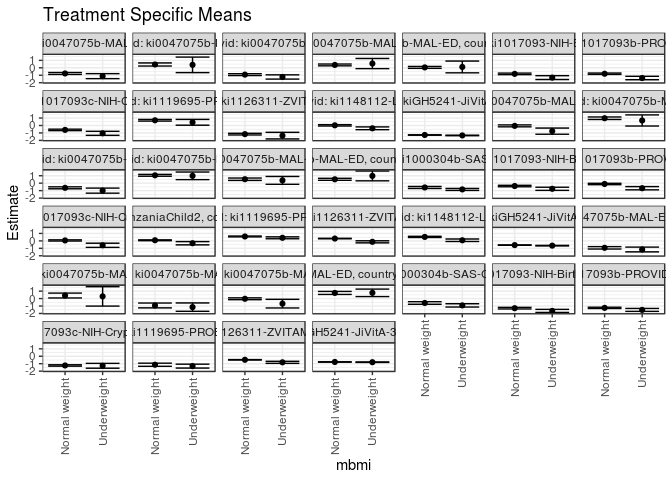

[figure not shown]

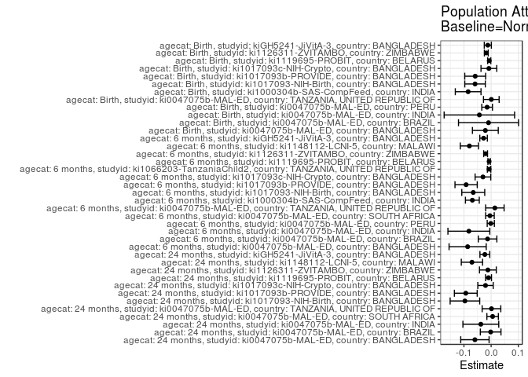

## Results Table

### Parameter: TSM

| agecat | studyid | country | intervention_level | baseline_level | estimate | ci_lower | ci_upper |
| --- | --- | --- | --- | --- | --- | --- | --- |
| Birth | ki0047075b-MAL-ED | BANGLADESH | Normal weight | NA | -0.9320855 | -1.0925597 | -0.7716113 |
| Birth | ki0047075b-MAL-ED | BANGLADESH | Underweight | NA | -1.1545970 | -1.4755240 | -0.8336700 |
| Birth | ki0047075b-MAL-ED | BRAZIL | Normal weight | NA | 0.4114286 | 0.0848121 | 0.7380451 |
| Birth | ki0047075b-MAL-ED | BRAZIL | Underweight | NA | 0.2940000 | -1.0086888 | 1.5966888 |
| Birth | ki0047075b-MAL-ED | INDIA | Normal weight | NA | -0.9245455 | -1.2487999 | -0.6002910 |
| Birth | ki0047075b-MAL-ED | INDIA | Underweight | NA | -1.1462500 | -1.7084286 | -0.5840714 |
| Birth | ki0047075b-MAL-ED | PERU | Normal weight | NA | -0.0281944 | -0.1526241 | 0.0962352 |
| Birth | ki0047075b-MAL-ED | PERU | Underweight | NA | -0.6820000 | -1.2614133 | -0.1025867 |
| Birth | ki0047075b-MAL-ED | TANZANIA, UNITED REPUBLIC OF | Normal weight | NA | 0.7576636 | 0.5539948 | 0.9613323 |
| Birth | ki0047075b-MAL-ED | TANZANIA, UNITED REPUBLIC OF | Underweight | NA | 0.7700000 | 0.2691531 | 1.2708469 |
| Birth | ki1000304b-SAS-CompFeed | INDIA | Normal weight | NA | -0.5907090 | -0.7636544 | -0.4177637 |
| Birth | ki1000304b-SAS-CompFeed | INDIA | Underweight | NA | -0.9136040 | -1.1342989 | -0.6929090 |
| Birth | ki1017093-NIH-Birth | BANGLADESH | Normal weight | NA | -1.2908069 | -1.3958264 | -1.1857873 |
| Birth | ki1017093-NIH-Birth | BANGLADESH | Underweight | NA | -1.6558801 | -1.8654219 | -1.4463382 |
| Birth | ki1017093b-PROVIDE | BANGLADESH | Normal weight | NA | -1.2475412 | -1.3333733 | -1.1617091 |
| Birth | ki1017093b-PROVIDE | BANGLADESH | Underweight | NA | -1.5209165 | -1.7168695 | -1.3249635 |
| Birth | ki1017093c-NIH-Crypto | BANGLADESH | Normal weight | NA | -1.2351367 | -1.3235183 | -1.1467552 |
| Birth | ki1017093c-NIH-Crypto | BANGLADESH | Underweight | NA | -1.2769994 | -1.6023776 | -0.9516212 |
| Birth | ki1119695-PROBIT | BELARUS | Normal weight | NA | -1.1359555 | -1.3457443 | -0.9261666 |
| Birth | ki1119695-PROBIT | BELARUS | Underweight | NA | -1.3216025 | -1.5828967 | -1.0603082 |
| Birth | ki1126311-ZVITAMBO | ZIMBABWE | Normal weight | NA | -0.4727532 | -0.5045119 | -0.4409944 |
| Birth | ki1126311-ZVITAMBO | ZIMBABWE | Underweight | NA | -0.8120329 | -0.9487411 | -0.6753247 |
| Birth | kiGH5241-JiVitA-3 | BANGLADESH | Normal weight | NA | -0.7659627 | -0.7893084 | -0.7426169 |
| Birth | kiGH5241-JiVitA-3 | BANGLADESH | Underweight | NA | -0.7972513 | -0.8248928 | -0.7696099 |
| 6 months | ki0047075b-MAL-ED | BANGLADESH | Normal weight | NA | -0.0512928 | -0.1810546 | 0.0784690 |
| 6 months | ki0047075b-MAL-ED | BANGLADESH | Underweight | NA | -0.7601707 | -1.1747416 | -0.3455999 |
| 6 months | ki0047075b-MAL-ED | BRAZIL | Normal weight | NA | 0.9779606 | 0.8096461 | 1.1462751 |
| 6 months | ki0047075b-MAL-ED | BRAZIL | Underweight | NA | 0.6750000 | -0.0698801 | 1.4198801 |
| 6 months | ki0047075b-MAL-ED | INDIA | Normal weight | NA | -0.6215507 | -0.7539760 | -0.4891254 |
| 6 months | ki0047075b-MAL-ED | INDIA | Underweight | NA | -1.0000634 | -1.3385577 | -0.6615692 |
| 6 months | ki0047075b-MAL-ED | PERU | Normal weight | NA | 1.0561298 | 0.9317231 | 1.1805366 |
| 6 months | ki0047075b-MAL-ED | PERU | Underweight | NA | 0.9870000 | 0.4781587 | 1.4958413 |
| 6 months | ki0047075b-MAL-ED | SOUTH AFRICA | Normal weight | NA | 0.5335468 | 0.3758513 | 0.6912424 |
| 6 months | ki0047075b-MAL-ED | SOUTH AFRICA | Underweight | NA | 0.3771429 | -0.1498294 | 0.9041151 |
| 6 months | ki0047075b-MAL-ED | TANZANIA, UNITED REPUBLIC OF | Normal weight | NA | 0.5225206 | 0.3875529 | 0.6574883 |
| 6 months | ki0047075b-MAL-ED | TANZANIA, UNITED REPUBLIC OF | Underweight | NA | 0.9763291 | 0.3149635 | 1.6376948 |
| 6 months | ki1000304b-SAS-CompFeed | INDIA | Normal weight | NA | -0.5735856 | -0.7078940 | -0.4392772 |
| 6 months | ki1000304b-SAS-CompFeed | INDIA | Underweight | NA | -0.8349899 | -0.9678920 | -0.7020879 |
| 6 months | ki1017093-NIH-Birth | BANGLADESH | Normal weight | NA | -0.3816843 | -0.4811235 | -0.2822451 |
| 6 months | ki1017093-NIH-Birth | BANGLADESH | Underweight | NA | -0.7535198 | -0.9656629 | -0.5413766 |
| 6 months | ki1017093b-PROVIDE | BANGLADESH | Normal weight | NA | -0.1067453 | -0.1968570 | -0.0166335 |
| 6 months | ki1017093b-PROVIDE | BANGLADESH | Underweight | NA | -0.6734764 | -0.8903645 | -0.4565884 |
| 6 months | ki1017093c-NIH-Crypto | BANGLADESH | Normal weight | NA | 0.0598729 | -0.0218742 | 0.1416201 |
| 6 months | ki1017093c-NIH-Crypto | BANGLADESH | Underweight | NA | -0.5916472 | -0.8731941 | -0.3101004 |
| 6 months | ki1066203-TanzaniaChild2 | TANZANIA, UNITED REPUBLIC OF | Normal weight | NA | 0.0850567 | 0.0304732 | 0.1396402 |
| 6 months | ki1066203-TanzaniaChild2 | TANZANIA, UNITED REPUBLIC OF | Underweight | NA | -0.3153619 | -0.5339401 | -0.0967836 |
| 6 months | ki1119695-PROBIT | BELARUS | Normal weight | NA | 0.5904036 | 0.5326956 | 0.6481116 |
| 6 months | ki1119695-PROBIT | BELARUS | Underweight | NA | 0.4119872 | 0.2849064 | 0.5390679 |
| 6 months | ki1126311-ZVITAMBO | ZIMBABWE | Normal weight | NA | 0.3152039 | 0.2870295 | 0.3433783 |
| 6 months | ki1126311-ZVITAMBO | ZIMBABWE | Underweight | NA | -0.1278831 | -0.2655653 | 0.0097991 |
| 6 months | ki1148112-LCNI-5 | MALAWI | Normal weight | NA | 0.5315501 | 0.4533412 | 0.6097590 |
| 6 months | ki1148112-LCNI-5 | MALAWI | Underweight | NA | 0.0829209 | -0.0857977 | 0.2516395 |
| 6 months | kiGH5241-JiVitA-3 | BANGLADESH | Normal weight | NA | -0.5653516 | -0.5884080 | -0.5422951 |
| 6 months | kiGH5241-JiVitA-3 | BANGLADESH | Underweight | NA | -0.6377854 | -0.6685350 | -0.6070358 |
| 24 months | ki0047075b-MAL-ED | BANGLADESH | Normal weight | NA | -0.7596673 | -0.8903885 | -0.6289461 |
| 24 months | ki0047075b-MAL-ED | BANGLADESH | Underweight | NA | -1.1178029 | -1.4548421 | -0.7807637 |
| 24 months | ki0047075b-MAL-ED | BRAZIL | Normal weight | NA | 0.4461317 | 0.2381826 | 0.6540808 |
| 24 months | ki0047075b-MAL-ED | BRAZIL | Underweight | NA | 0.3966667 | -0.6451983 | 1.4385316 |
| 24 months | ki0047075b-MAL-ED | INDIA | Normal weight | NA | -0.9140228 | -1.0390618 | -0.7889839 |
| 24 months | ki0047075b-MAL-ED | INDIA | Underweight | NA | -1.2296468 | -1.5180631 | -0.9412305 |
| 24 months | ki0047075b-MAL-ED | SOUTH AFRICA | Normal weight | NA | 0.3861417 | 0.2630585 | 0.5092249 |
| 24 months | ki0047075b-MAL-ED | SOUTH AFRICA | Underweight | NA | 0.5700000 | -0.1123856 | 1.2523856 |
| 24 months | ki0047075b-MAL-ED | TANZANIA, UNITED REPUBLIC OF | Normal weight | NA | 0.0535474 | -0.0736795 | 0.1807743 |
| 24 months | ki0047075b-MAL-ED | TANZANIA, UNITED REPUBLIC OF | Underweight | NA | 0.1131864 | -0.6769730 | 0.9033457 |
| 24 months | ki1017093-NIH-Birth | BANGLADESH | Normal weight | NA | -0.8152166 | -0.9183595 | -0.7120736 |
| 24 months | ki1017093-NIH-Birth | BANGLADESH | Underweight | NA | -1.3154961 | -1.5744173 | -1.0565749 |
| 24 months | ki1017093b-PROVIDE | BANGLADESH | Normal weight | NA | -0.7982251 | -0.8884319 | -0.7080184 |
| 24 months | ki1017093b-PROVIDE | BANGLADESH | Underweight | NA | -1.3719035 | -1.6015490 | -1.1422581 |
| 24 months | ki1017093c-NIH-Crypto | BANGLADESH | Normal weight | NA | -0.5896632 | -0.6890382 | -0.4902882 |
| 24 months | ki1017093c-NIH-Crypto | BANGLADESH | Underweight | NA | -1.0491630 | -1.3207250 | -0.7776010 |
| 24 months | ki1119695-PROBIT | BELARUS | Normal weight | NA | 0.6976793 | 0.5873495 | 0.8080091 |
| 24 months | ki1119695-PROBIT | BELARUS | Underweight | NA | 0.4297538 | 0.0405465 | 0.8189611 |
| 24 months | ki1126311-ZVITAMBO | ZIMBABWE | Normal weight | NA | -1.1598990 | -1.2731809 | -1.0466171 |
| 24 months | ki1126311-ZVITAMBO | ZIMBABWE | Underweight | NA | -1.3618852 | -1.8054577 | -0.9183126 |
| 24 months | ki1148112-LCNI-5 | MALAWI | Normal weight | NA | 0.0237001 | -0.0664890 | 0.1138892 |
| 24 months | ki1148112-LCNI-5 | MALAWI | Underweight | NA | -0.3781050 | -0.5648475 | -0.1913626 |
| 24 months | kiGH5241-JiVitA-3 | BANGLADESH | Normal weight | NA | -1.2739302 | -1.3035199 | -1.2443405 |
| 24 months | kiGH5241-JiVitA-3 | BANGLADESH | Underweight | NA | -1.3340599 | -1.3708616 | -1.2972582 |

### Parameter: E(Y)

| agecat | studyid | country | intervention_level | baseline_level | estimate | ci_lower | ci_upper |
| --- | --- | --- | --- | --- | --- | --- | --- |
| Birth | ki0047075b-MAL-ED | BANGLADESH | NA | NA | -0.9533493 | -1.0984355 | -0.8082631 |
| Birth | ki0047075b-MAL-ED | BRAZIL | NA | NA | 0.4018033 | 0.0834093 | 0.7201973 |
| Birth | ki0047075b-MAL-ED | INDIA | NA | NA | -0.9678049 | -1.2522118 | -0.6833979 |
| Birth | ki0047075b-MAL-ED | PERU | NA | NA | -0.0429864 | -0.1658406 | 0.0798678 |
| Birth | ki0047075b-MAL-ED | TANZANIA, UNITED REPUBLIC OF | NA | NA | 0.7583186 | 0.5636385 | 0.9529987 |
| Birth | ki1000304b-SAS-CompFeed | INDIA | NA | NA | -0.6752218 | -0.8548888 | -0.4955547 |
| Birth | ki1017093-NIH-Birth | BANGLADESH | NA | NA | -1.3499217 | -1.4444634 | -1.2553801 |
| Birth | ki1017093b-PROVIDE | BANGLADESH | NA | NA | -1.3060980 | -1.3843247 | -1.2278714 |
| Birth | ki1017093c-NIH-Crypto | BANGLADESH | NA | NA | -1.2434730 | -1.3276901 | -1.1592559 |
| Birth | ki1119695-PROBIT | BELARUS | NA | NA | -1.1429259 | -1.3532676 | -0.9325843 |
| Birth | ki1126311-ZVITAMBO | ZIMBABWE | NA | NA | -0.4905338 | -0.5214551 | -0.4596125 |
| Birth | kiGH5241-JiVitA-3 | BANGLADESH | NA | NA | -0.7781583 | -0.7971779 | -0.7591388 |
| 6 months | ki0047075b-MAL-ED | BANGLADESH | NA | NA | -0.1376763 | -0.2664642 | -0.0088885 |
| 6 months | ki0047075b-MAL-ED | BRAZIL | NA | NA | 0.9648518 | 0.8004118 | 1.1292917 |
| 6 months | ki0047075b-MAL-ED | INDIA | NA | NA | -0.7034149 | -0.8300527 | -0.5767771 |
| 6 months | ki0047075b-MAL-ED | PERU | NA | NA | 1.0548591 | 0.9328922 | 1.1768259 |
| 6 months | ki0047075b-MAL-ED | SOUTH AFRICA | NA | NA | 0.5291499 | 0.3751396 | 0.6831602 |
| 6 months | ki0047075b-MAL-ED | TANZANIA, UNITED REPUBLIC OF | NA | NA | 0.5362213 | 0.4049390 | 0.6675036 |
| 6 months | ki1000304b-SAS-CompFeed | INDIA | NA | NA | -0.6426305 | -0.7702214 | -0.5150396 |
| 6 months | ki1017093-NIH-Birth | BANGLADESH | NA | NA | -0.4474038 | -0.5378167 | -0.3569909 |
| 6 months | ki1017093b-PROVIDE | BANGLADESH | NA | NA | -0.1987071 | -0.2815473 | -0.1158669 |
| 6 months | ki1017093c-NIH-Crypto | BANGLADESH | NA | NA | 0.0297622 | -0.0491685 | 0.1086930 |
| 6 months | ki1066203-TanzaniaChild2 | TANZANIA, UNITED REPUBLIC OF | NA | NA | 0.0775172 | 0.0241750 | 0.1308595 |
| 6 months | ki1119695-PROBIT | BELARUS | NA | NA | 0.5829956 | 0.5247249 | 0.6412663 |
| 6 months | ki1126311-ZVITAMBO | ZIMBABWE | NA | NA | 0.2948332 | 0.2672524 | 0.3224139 |
| 6 months | ki1148112-LCNI-5 | MALAWI | NA | NA | 0.4515550 | 0.3802638 | 0.5228463 |
| 6 months | kiGH5241-JiVitA-3 | BANGLADESH | NA | NA | -0.5931545 | -0.6127055 | -0.5736036 |
| 24 months | ki0047075b-MAL-ED | BANGLADESH | NA | NA | -0.8192925 | -0.9412667 | -0.6973182 |
| 24 months | ki0047075b-MAL-ED | BRAZIL | NA | NA | 0.4443651 | 0.2404149 | 0.6483153 |
| 24 months | ki0047075b-MAL-ED | INDIA | NA | NA | -0.9519248 | -1.0678488 | -0.8360007 |
| 24 months | ki0047075b-MAL-ED | SOUTH AFRICA | NA | NA | 0.3916417 | 0.2704414 | 0.5128421 |
| 24 months | ki0047075b-MAL-ED | TANZANIA, UNITED REPUBLIC OF | NA | NA | 0.0547975 | -0.0703378 | 0.1799328 |
| 24 months | ki1017093-NIH-Birth | BANGLADESH | NA | NA | -0.9115790 | -1.0095022 | -0.8136559 |
| 24 months | ki1017093b-PROVIDE | BANGLADESH | NA | NA | -0.8914360 | -0.9741797 | -0.8086923 |
| 24 months | ki1017093c-NIH-Crypto | BANGLADESH | NA | NA | -0.6103502 | -0.7050157 | -0.5156847 |
| 24 months | ki1119695-PROBIT | BELARUS | NA | NA | 0.6880695 | 0.5737062 | 0.8024328 |
| 24 months | ki1126311-ZVITAMBO | ZIMBABWE | NA | NA | -1.1718579 | -1.2809898 | -1.0627260 |
| 24 months | ki1148112-LCNI-5 | MALAWI | NA | NA | -0.0468717 | -0.1290135 | 0.0352701 |
| 24 months | kiGH5241-JiVitA-3 | BANGLADESH | NA | NA | -1.2970642 | -1.3203662 | -1.2737621 |

### Parameter: ATE

| agecat | studyid | country | intervention_level | baseline_level | estimate | ci_lower | ci_upper |
| --- | --- | --- | --- | --- | --- | --- | --- |
| Birth | ki0047075b-MAL-ED | BANGLADESH | Normal weight | Normal weight | 0.0000000 | 0.0000000 | 0.0000000 |
| Birth | ki0047075b-MAL-ED | BANGLADESH | Underweight | Normal weight | -0.2225115 | -0.5820991 | 0.1370762 |
| Birth | ki0047075b-MAL-ED | BRAZIL | Normal weight | Normal weight | 0.0000000 | 0.0000000 | 0.0000000 |
| Birth | ki0047075b-MAL-ED | BRAZIL | Underweight | Normal weight | -0.1174286 | -1.4604388 | 1.2255816 |
| Birth | ki0047075b-MAL-ED | INDIA | Normal weight | Normal weight | 0.0000000 | 0.0000000 | 0.0000000 |
| Birth | ki0047075b-MAL-ED | INDIA | Underweight | Normal weight | -0.2217045 | -0.8706928 | 0.4272837 |
| Birth | ki0047075b-MAL-ED | PERU | Normal weight | Normal weight | 0.0000000 | 0.0000000 | 0.0000000 |
| Birth | ki0047075b-MAL-ED | PERU | Underweight | Normal weight | -0.6538056 | -1.2464290 | -0.0611821 |
| Birth | ki0047075b-MAL-ED | TANZANIA, UNITED REPUBLIC OF | Normal weight | Normal weight | 0.0000000 | 0.0000000 | 0.0000000 |
| Birth | ki0047075b-MAL-ED | TANZANIA, UNITED REPUBLIC OF | Underweight | Normal weight | 0.0123364 | -0.5283378 | 0.5530107 |
| Birth | ki1000304b-SAS-CompFeed | INDIA | Normal weight | Normal weight | 0.0000000 | 0.0000000 | 0.0000000 |
| Birth | ki1000304b-SAS-CompFeed | INDIA | Underweight | Normal weight | -0.3228949 | -0.4941872 | -0.1516026 |
| Birth | ki1017093-NIH-Birth | BANGLADESH | Normal weight | Normal weight | 0.0000000 | 0.0000000 | 0.0000000 |
| Birth | ki1017093-NIH-Birth | BANGLADESH | Underweight | Normal weight | -0.3650732 | -0.5984141 | -0.1317323 |
| Birth | ki1017093b-PROVIDE | BANGLADESH | Normal weight | Normal weight | 0.0000000 | 0.0000000 | 0.0000000 |
| Birth | ki1017093b-PROVIDE | BANGLADESH | Underweight | Normal weight | -0.2733753 | -0.4876854 | -0.0590652 |
| Birth | ki1017093c-NIH-Crypto | BANGLADESH | Normal weight | Normal weight | 0.0000000 | 0.0000000 | 0.0000000 |
| Birth | ki1017093c-NIH-Crypto | BANGLADESH | Underweight | Normal weight | -0.0418627 | -0.3788117 | 0.2950863 |
| Birth | ki1119695-PROBIT | BELARUS | Normal weight | Normal weight | 0.0000000 | 0.0000000 | 0.0000000 |
| Birth | ki1119695-PROBIT | BELARUS | Underweight | Normal weight | -0.1856470 | -0.3328714 | -0.0384225 |
| Birth | ki1126311-ZVITAMBO | ZIMBABWE | Normal weight | Normal weight | 0.0000000 | 0.0000000 | 0.0000000 |
| Birth | ki1126311-ZVITAMBO | ZIMBABWE | Underweight | Normal weight | -0.3392797 | -0.4796360 | -0.1989233 |
| Birth | kiGH5241-JiVitA-3 | BANGLADESH | Normal weight | Normal weight | 0.0000000 | 0.0000000 | 0.0000000 |
| Birth | kiGH5241-JiVitA-3 | BANGLADESH | Underweight | Normal weight | -0.0312886 | -0.0647225 | 0.0021453 |
| 6 months | ki0047075b-MAL-ED | BANGLADESH | Normal weight | Normal weight | 0.0000000 | 0.0000000 | 0.0000000 |
| 6 months | ki0047075b-MAL-ED | BANGLADESH | Underweight | Normal weight | -0.7088779 | -1.1435106 | -0.2742453 |
| 6 months | ki0047075b-MAL-ED | BRAZIL | Normal weight | Normal weight | 0.0000000 | 0.0000000 | 0.0000000 |
| 6 months | ki0047075b-MAL-ED | BRAZIL | Underweight | Normal weight | -0.3029606 | -1.0666204 | 0.4606991 |
| 6 months | ki0047075b-MAL-ED | INDIA | Normal weight | Normal weight | 0.0000000 | 0.0000000 | 0.0000000 |
| 6 months | ki0047075b-MAL-ED | INDIA | Underweight | Normal weight | -0.3785127 | -0.7431095 | -0.0139160 |
| 6 months | ki0047075b-MAL-ED | PERU | Normal weight | Normal weight | 0.0000000 | 0.0000000 | 0.0000000 |
| 6 months | ki0047075b-MAL-ED | PERU | Underweight | Normal weight | -0.0691298 | -0.5929586 | 0.4546989 |
| 6 months | ki0047075b-MAL-ED | SOUTH AFRICA | Normal weight | Normal weight | 0.0000000 | 0.0000000 | 0.0000000 |
| 6 months | ki0047075b-MAL-ED | SOUTH AFRICA | Underweight | Normal weight | -0.1564040 | -0.7064654 | 0.3936575 |
| 6 months | ki0047075b-MAL-ED | TANZANIA, UNITED REPUBLIC OF | Normal weight | Normal weight | 0.0000000 | 0.0000000 | 0.0000000 |
| 6 months | ki0047075b-MAL-ED | TANZANIA, UNITED REPUBLIC OF | Underweight | Normal weight | 0.4538085 | -0.2244291 | 1.1320461 |
| 6 months | ki1000304b-SAS-CompFeed | INDIA | Normal weight | Normal weight | 0.0000000 | 0.0000000 | 0.0000000 |
| 6 months | ki1000304b-SAS-CompFeed | INDIA | Underweight | Normal weight | -0.2614043 | -0.3637852 | -0.1590234 |
| 6 months | ki1017093-NIH-Birth | BANGLADESH | Normal weight | Normal weight | 0.0000000 | 0.0000000 | 0.0000000 |
| 6 months | ki1017093-NIH-Birth | BANGLADESH | Underweight | Normal weight | -0.3718354 | -0.6068243 | -0.1368465 |
| 6 months | ki1017093b-PROVIDE | BANGLADESH | Normal weight | Normal weight | 0.0000000 | 0.0000000 | 0.0000000 |
| 6 months | ki1017093b-PROVIDE | BANGLADESH | Underweight | Normal weight | -0.5667312 | -0.8011594 | -0.3323030 |
| 6 months | ki1017093c-NIH-Crypto | BANGLADESH | Normal weight | Normal weight | 0.0000000 | 0.0000000 | 0.0000000 |
| 6 months | ki1017093c-NIH-Crypto | BANGLADESH | Underweight | Normal weight | -0.6515202 | -0.9450069 | -0.3580334 |
| 6 months | ki1066203-TanzaniaChild2 | TANZANIA, UNITED REPUBLIC OF | Normal weight | Normal weight | 0.0000000 | 0.0000000 | 0.0000000 |
| 6 months | ki1066203-TanzaniaChild2 | TANZANIA, UNITED REPUBLIC OF | Underweight | Normal weight | -0.4004186 | -0.6256027 | -0.1752344 |
| 6 months | ki1119695-PROBIT | BELARUS | Normal weight | Normal weight | 0.0000000 | 0.0000000 | 0.0000000 |
| 6 months | ki1119695-PROBIT | BELARUS | Underweight | Normal weight | -0.1784164 | -0.2905704 | -0.0662624 |
| 6 months | ki1126311-ZVITAMBO | ZIMBABWE | Normal weight | Normal weight | 0.0000000 | 0.0000000 | 0.0000000 |
| 6 months | ki1126311-ZVITAMBO | ZIMBABWE | Underweight | Normal weight | -0.4430870 | -0.5835614 | -0.3026126 |
| 6 months | ki1148112-LCNI-5 | MALAWI | Normal weight | Normal weight | 0.0000000 | 0.0000000 | 0.0000000 |
| 6 months | ki1148112-LCNI-5 | MALAWI | Underweight | Normal weight | -0.4486292 | -0.6350351 | -0.2622233 |
| 6 months | kiGH5241-JiVitA-3 | BANGLADESH | Normal weight | Normal weight | 0.0000000 | 0.0000000 | 0.0000000 |
| 6 months | kiGH5241-JiVitA-3 | BANGLADESH | Underweight | Normal weight | -0.0724338 | -0.1083990 | -0.0364686 |
| 24 months | ki0047075b-MAL-ED | BANGLADESH | Normal weight | Normal weight | 0.0000000 | 0.0000000 | 0.0000000 |
| 24 months | ki0047075b-MAL-ED | BANGLADESH | Underweight | Normal weight | -0.3581356 | -0.7194620 | 0.0031908 |
| 24 months | ki0047075b-MAL-ED | BRAZIL | Normal weight | Normal weight | 0.0000000 | 0.0000000 | 0.0000000 |
| 24 months | ki0047075b-MAL-ED | BRAZIL | Underweight | Normal weight | -0.0494650 | -1.1118799 | 1.0129498 |
| 24 months | ki0047075b-MAL-ED | INDIA | Normal weight | Normal weight | 0.0000000 | 0.0000000 | 0.0000000 |
| 24 months | ki0047075b-MAL-ED | INDIA | Underweight | Normal weight | -0.3156240 | -0.6310977 | -0.0001503 |
| 24 months | ki0047075b-MAL-ED | SOUTH AFRICA | Normal weight | Normal weight | 0.0000000 | 0.0000000 | 0.0000000 |
| 24 months | ki0047075b-MAL-ED | SOUTH AFRICA | Underweight | Normal weight | 0.1838583 | -0.5095388 | 0.8772554 |
| 24 months | ki0047075b-MAL-ED | TANZANIA, UNITED REPUBLIC OF | Normal weight | Normal weight | 0.0000000 | 0.0000000 | 0.0000000 |
| 24 months | ki0047075b-MAL-ED | TANZANIA, UNITED REPUBLIC OF | Underweight | Normal weight | 0.0596390 | -0.7408930 | 0.8601709 |
| 24 months | ki1017093-NIH-Birth | BANGLADESH | Normal weight | Normal weight | 0.0000000 | 0.0000000 | 0.0000000 |
| 24 months | ki1017093-NIH-Birth | BANGLADESH | Underweight | Normal weight | -0.5002795 | -0.7791660 | -0.2213931 |
| 24 months | ki1017093b-PROVIDE | BANGLADESH | Normal weight | Normal weight | 0.0000000 | 0.0000000 | 0.0000000 |
| 24 months | ki1017093b-PROVIDE | BANGLADESH | Underweight | Normal weight | -0.5736784 | -0.8204873 | -0.3268694 |
| 24 months | ki1017093c-NIH-Crypto | BANGLADESH | Normal weight | Normal weight | 0.0000000 | 0.0000000 | 0.0000000 |
| 24 months | ki1017093c-NIH-Crypto | BANGLADESH | Underweight | Normal weight | -0.4594998 | -0.7492132 | -0.1697865 |
| 24 months | ki1119695-PROBIT | BELARUS | Normal weight | Normal weight | 0.0000000 | 0.0000000 | 0.0000000 |
| 24 months | ki1119695-PROBIT | BELARUS | Underweight | Normal weight | -0.2679255 | -0.6087583 | 0.0729074 |
| 24 months | ki1126311-ZVITAMBO | ZIMBABWE | Normal weight | Normal weight | 0.0000000 | 0.0000000 | 0.0000000 |
| 24 months | ki1126311-ZVITAMBO | ZIMBABWE | Underweight | Normal weight | -0.2019862 | -0.6597976 | 0.2558252 |
| 24 months | ki1148112-LCNI-5 | MALAWI | Normal weight | Normal weight | 0.0000000 | 0.0000000 | 0.0000000 |
| 24 months | ki1148112-LCNI-5 | MALAWI | Underweight | Normal weight | -0.4018051 | -0.6091081 | -0.1945021 |
| 24 months | kiGH5241-JiVitA-3 | BANGLADESH | Normal weight | Normal weight | 0.0000000 | 0.0000000 | 0.0000000 |
| 24 months | kiGH5241-JiVitA-3 | BANGLADESH | Underweight | Normal weight | -0.0601297 | -0.1070084 | -0.0132511 |

### Parameter: PAR

| agecat | studyid | country | intervention_level | baseline_level | estimate | ci_lower | ci_upper |
| --- | --- | --- | --- | --- | --- | --- | --- |
| Birth | ki0047075b-MAL-ED | BANGLADESH | Normal weight | NA | -0.0212638 | -0.0687643 | 0.0262368 |
| Birth | ki0047075b-MAL-ED | BRAZIL | Normal weight | NA | -0.0096253 | -0.1200094 | 0.1007588 |
| Birth | ki0047075b-MAL-ED | INDIA | Normal weight | NA | -0.0432594 | -0.1727854 | 0.0862665 |
| Birth | ki0047075b-MAL-ED | PERU | Normal weight | NA | -0.0147920 | -0.0344019 | 0.0048180 |
| Birth | ki0047075b-MAL-ED | TANZANIA, UNITED REPUBLIC OF | Normal weight | NA | 0.0006550 | -0.0280579 | 0.0293680 |
| Birth | ki1000304b-SAS-CompFeed | INDIA | Normal weight | NA | -0.0845127 | -0.1317662 | -0.0372593 |
| Birth | ki1017093-NIH-Birth | BANGLADESH | Normal weight | NA | -0.0591149 | -0.0968107 | -0.0214190 |
| Birth | ki1017093b-PROVIDE | BANGLADESH | Normal weight | NA | -0.0585568 | -0.0969632 | -0.0201505 |
| Birth | ki1017093c-NIH-Crypto | BANGLADESH | Normal weight | NA | -0.0083363 | -0.0373270 | 0.0206544 |
| Birth | ki1119695-PROBIT | BELARUS | Normal weight | NA | -0.0069704 | -0.0127250 | -0.0012159 |
| Birth | ki1126311-ZVITAMBO | ZIMBABWE | Normal weight | NA | -0.0177806 | -0.0249212 | -0.0106399 |
| Birth | kiGH5241-JiVitA-3 | BANGLADESH | Normal weight | NA | -0.0121957 | -0.0252310 | 0.0008396 |
| 6 months | ki0047075b-MAL-ED | BANGLADESH | Normal weight | NA | -0.0863835 | -0.1546889 | -0.0180781 |
| 6 months | ki0047075b-MAL-ED | BRAZIL | Normal weight | NA | -0.0131089 | -0.0472021 | 0.0209844 |
| 6 months | ki0047075b-MAL-ED | INDIA | Normal weight | NA | -0.0818642 | -0.1588337 | -0.0048947 |
| 6 months | ki0047075b-MAL-ED | PERU | Normal weight | NA | -0.0012708 | -0.0144131 | 0.0118715 |
| 6 months | ki0047075b-MAL-ED | SOUTH AFRICA | Normal weight | NA | -0.0043969 | -0.0201917 | 0.0113979 |
| 6 months | ki0047075b-MAL-ED | TANZANIA, UNITED REPUBLIC OF | Normal weight | NA | 0.0137007 | -0.0202174 | 0.0476189 |
| 6 months | ki1000304b-SAS-CompFeed | INDIA | Normal weight | NA | -0.0690449 | -0.0944764 | -0.0436133 |
| 6 months | ki1017093-NIH-Birth | BANGLADESH | Normal weight | NA | -0.0657194 | -0.1078784 | -0.0235605 |
| 6 months | ki1017093b-PROVIDE | BANGLADESH | Normal weight | NA | -0.0919618 | -0.1329063 | -0.0510173 |
| 6 months | ki1017093c-NIH-Crypto | BANGLADESH | Normal weight | NA | -0.0301107 | -0.0589464 | -0.0012750 |
| 6 months | ki1066203-TanzaniaChild2 | TANZANIA, UNITED REPUBLIC OF | Normal weight | NA | -0.0075395 | -0.0138994 | -0.0011795 |
| 6 months | ki1119695-PROBIT | BELARUS | Normal weight | NA | -0.0074079 | -0.0117512 | -0.0030647 |
| 6 months | ki1126311-ZVITAMBO | ZIMBABWE | Normal weight | NA | -0.0203707 | -0.0274836 | -0.0132579 |
| 6 months | ki1148112-LCNI-5 | MALAWI | Normal weight | NA | -0.0799951 | -0.1134742 | -0.0465159 |
| 6 months | kiGH5241-JiVitA-3 | BANGLADESH | Normal weight | NA | -0.0278030 | -0.0416411 | -0.0139649 |
| 24 months | ki0047075b-MAL-ED | BANGLADESH | Normal weight | NA | -0.0596251 | -0.1117231 | -0.0075272 |
| 24 months | ki0047075b-MAL-ED | BRAZIL | Normal weight | NA | -0.0017666 | -0.0397355 | 0.0362023 |
| 24 months | ki0047075b-MAL-ED | INDIA | Normal weight | NA | -0.0379020 | -0.1037960 | 0.0279921 |
| 24 months | ki0047075b-MAL-ED | SOUTH AFRICA | Normal weight | NA | 0.0055000 | -0.0156289 | 0.0266289 |
| 24 months | ki0047075b-MAL-ED | TANZANIA, UNITED REPUBLIC OF | Normal weight | NA | 0.0012501 | -0.0330547 | 0.0355550 |
| 24 months | ki1017093-NIH-Birth | BANGLADESH | Normal weight | NA | -0.0963625 | -0.1507054 | -0.0420196 |
| 24 months | ki1017093b-PROVIDE | BANGLADESH | Normal weight | NA | -0.0932108 | -0.1351403 | -0.0512814 |
| 24 months | ki1017093c-NIH-Crypto | BANGLADESH | Normal weight | NA | -0.0206870 | -0.0489778 | 0.0076038 |
| 24 months | ki1119695-PROBIT | BELARUS | Normal weight | NA | -0.0096098 | -0.0205450 | 0.0013254 |
| 24 months | ki1126311-ZVITAMBO | ZIMBABWE | Normal weight | NA | -0.0119590 | -0.0428083 | 0.0188904 |
| 24 months | ki1148112-LCNI-5 | MALAWI | Normal weight | NA | -0.0705717 | -0.1097060 | -0.0314375 |
| 24 months | kiGH5241-JiVitA-3 | BANGLADESH | Normal weight | NA | -0.0231340 | -0.0411891 | -0.0050788 |